# Homework 6

Elizabeth Jamison

2/19/2020

### Open libraries

```r
library(ggplot2) # for graphics
library(MASS) # for maximum likelihood estimation
```

### My data

```r
z <- read.table("TreeDBHdata.csv",header=TRUE,sep=",", stringsAsFactors=FALSE)
str(z)
```

```
## 'data.frame':    2123 obs. of  2 variables:
##  $ ID   : int  1 2 3 4 5 6 7 8 9 10 ...
##  $ myVar: num  35.4 15.3 28.9 13.7 11.7 10.8 11.7 32.8 13.5 15 ...
```

```r
summary(z)
```

```
##        ID             myVar
##  Min.   :   1.0   Min.   : 7.458
##  1st Qu.: 531.5   1st Qu.:12.500
##  Median :1062.0   Median :19.000
##  Mean   : 960.8   Mean   :21.348
##  3rd Qu.:1468.0   3rd Qu.:28.400
##  Max.   :1468.0   Max.   :67.017
```

Using the best-fitting distribution, go back to the code and get the maximum likelihood parameters. Use those to simulate a new data set, with the same length as your original vector, and plot that in a histogram and add the probability density curve. Right below that, generate a fresh histogram plot of the original data, and also include the probability density curve.

### Best fit : Gamma

### Simulate a new dataset

```r
gammaPars <- fitdistr(z$myVar,"gamma")
print(gammaPars)
```

```
##       shape         rate
##   4.383713060   0.205344865
##  (0.129745747) (0.006439477)
```

```r
shapeML <- gammaPars$estimate["shape"]
rateML <- gammaPars$estimate["rate"]

sample_num <- length(z$myVar)

sim_data <- data.frame("Data"=rgamma(sample_num, shapeML, rateML))
head(sim_data)
```

```
##        Data
## 1 41.886705
## 2 32.730485
## 3 18.722945
## 4 22.379111
## 5 19.221444
## 6  7.086023
```

### Plot new dataset with probability density curve

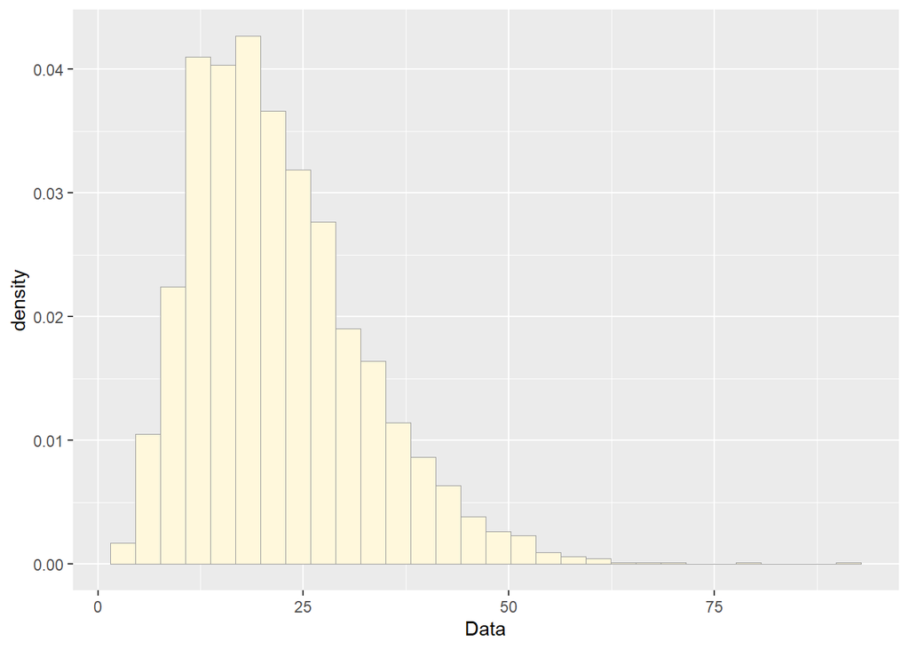

```r
p_sim <- ggplot(data=sim_data, aes(x=Data, y=..density..)) +
  geom_histogram(color="grey60",fill="cornsilk",size=0.2)
print(p_sim)
```

```r
xval <- seq(0,max(z$myVar),len=length(z$myVar))

stat5 <- stat_function(aes(x = xval, y = ..y..), fun = dgamma, colour="brown", n = length(z$myVar), args = list(shape=shapeML, rate=rateML))
 p_sim + stat5
```

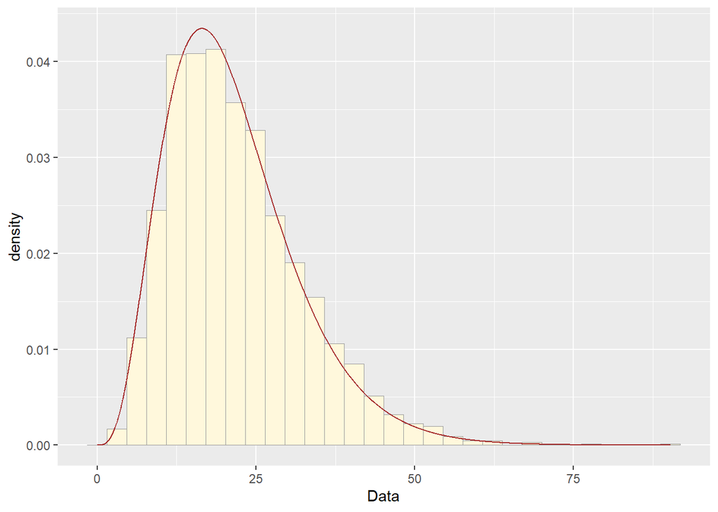

### Plot my data with gamma probability density curve

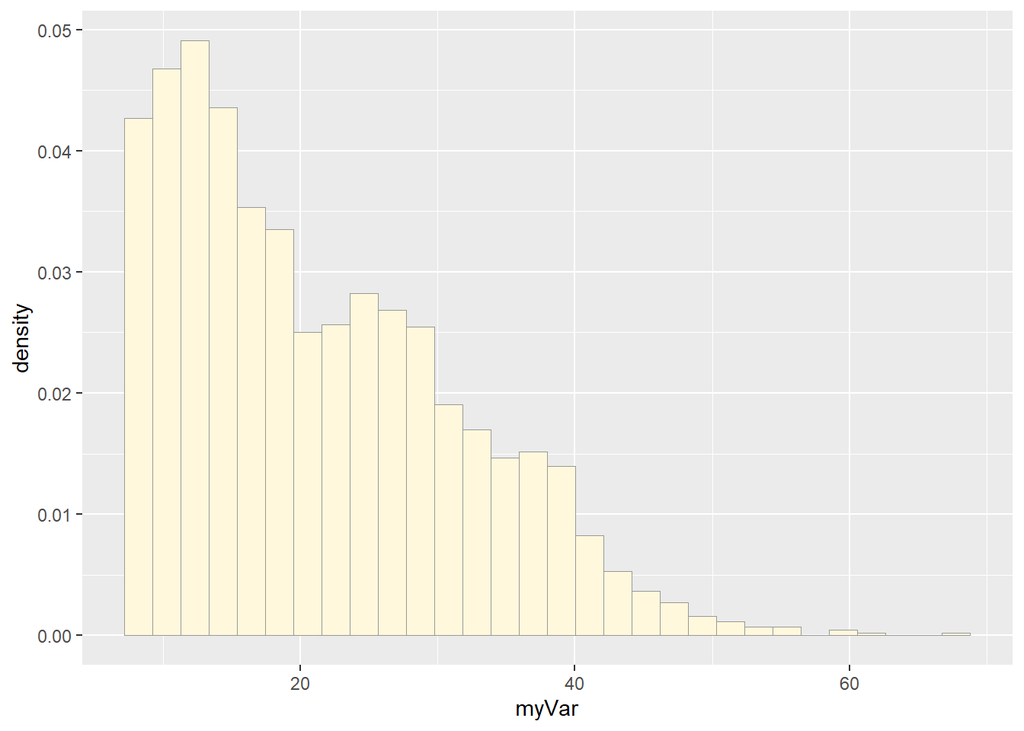

```r
p1 <- ggplot(data=z, aes(x=myVar, y=..density..)) +
  geom_histogram(color="grey60",fill="cornsilk",size=0.2)
print(p1)
```

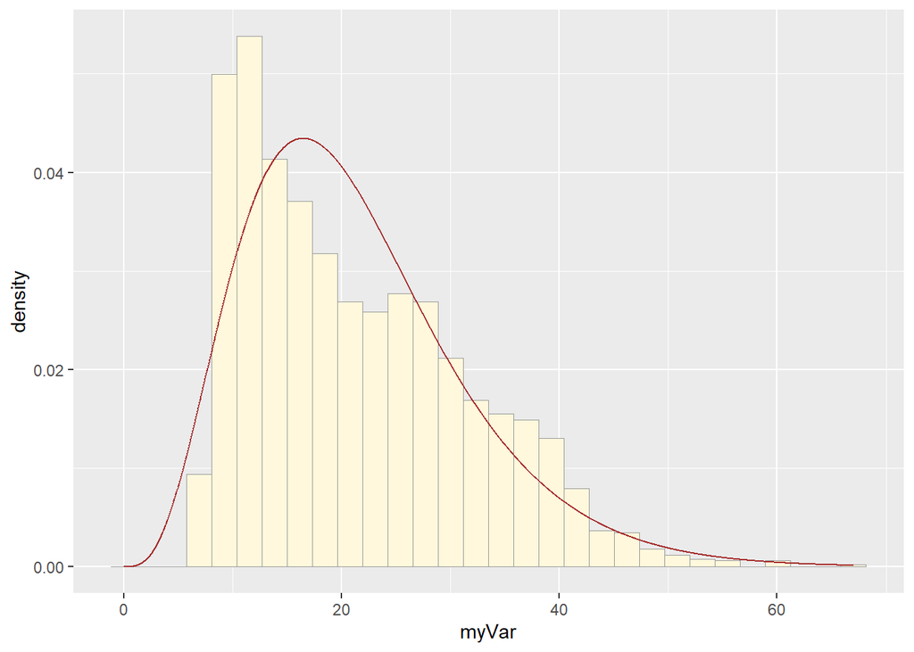

```r
stat4 <- stat_function(aes(x = xval, y = ..y..), fun = dgamma, colour="brown", n = length(z$myVar), args = list(shape=shapeML, rate=rateML))

print(p1 + stat4)
```

### Question

How do the two histogram profiles compare? Do you think the model is doing a good job of simulating realistic data that match your original measurements? Why or why not?

The simulated data histogram has a smoother distribution with a clearer mean. The gamma probability density curve best fits the simulated data histogram, which is to be expected since the simulated data was generated directly from the gamma distribution of the curve. I do think that the model is doing a good job of simulating data that matches my original data. I think this because the simulated data histogram exhibits a similar shape seen in my data’s histogram. Both datasets are centered around a similar mean of ~20 cm with a larger tail on the right side than the left. The model is definitely not perfect, but I think it is an adequate simulation.

### Determining probability curve that best fits my data

### Read in vector data

```r
# quick and dirty, a truncated normal distribution to work on the solution set

#z <- rnorm(n=3000,mean=0.2)
#z <- data.frame(1:3000,z)
#names(z) <- list("ID","myVar")
#z <- z[z$myVar>0,]
#str(z)
#summary(z$myVar)
#head(z)
```

### Plot histogram of data

Plot a histogram of the data, using a modification of the code from lecture. Here we are switching from qplot to ggplot for more graphics options. We are also rescaling the y axis of the histogram from counts to density, so that the area under the histogram equals 1.0.

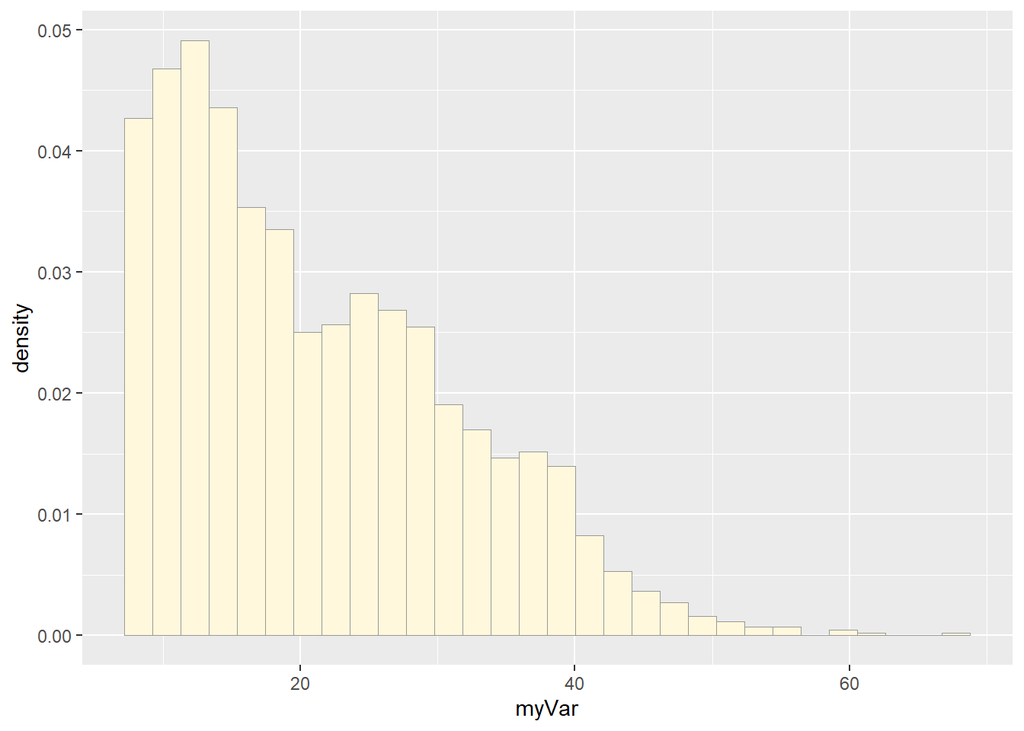

```r
p1 <- ggplot(data=z, aes(x=myVar, y=..density..)) +
  geom_histogram(color="grey60",fill="cornsilk",size=0.2)
print(p1)
```

### Add empirical density curve

Now modify the code to add in a kernel density plot of the data. This is an empirical curve that is fitted to the data. It does not assume any particular probability distribution, but it smooths out the shape of the histogram:

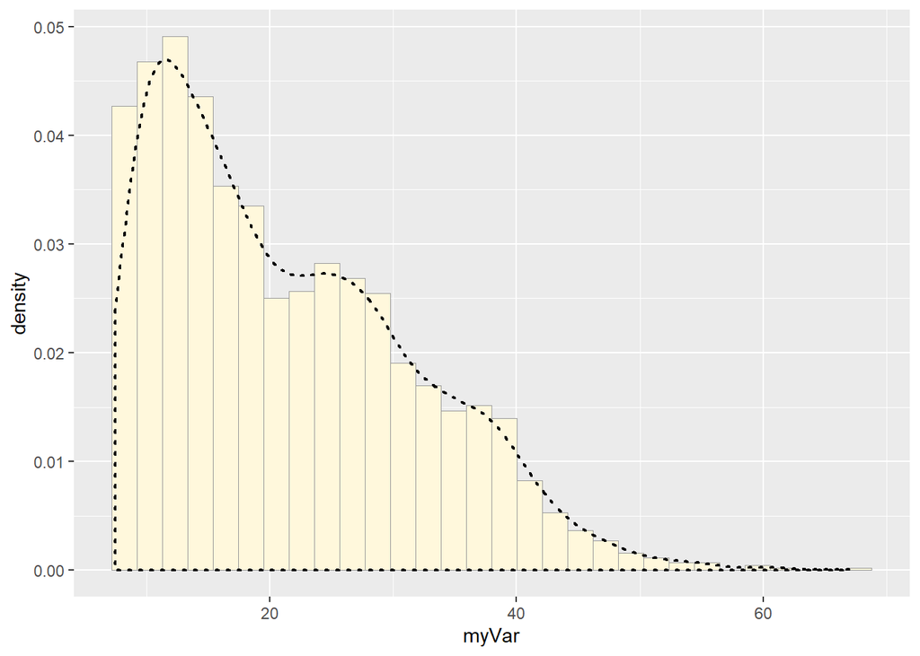

```r
p1 <-  p1 +  geom_density(linetype="dotted",size=0.75)
print(p1)
```

### Get maximum liklihood parameters for normal

Next, fit a normal distribution to your data and grab the maximum likelihood estimators of the two parameters of the normal, the mean and the variance:

```r
normPars <- fitdistr(z$myVar,"normal")
print(normPars)
```

```
##       mean          sd
##   21.3480597   10.3620697
##  ( 0.2248907) ( 0.1590217)
```

```r
str(normPars)
```

```
## List of 5
##  $ estimate: Named num [1:2] 21.3 10.4
##   ..- attr(*, "names")= chr [1:2] "mean" "sd"
##  $ sd      : Named num [1:2] 0.225 0.159
##   ..- attr(*, "names")= chr [1:2] "mean" "sd"
##  $ vcov    : num [1:2, 1:2] 0.0506 0 0 0.0253
##   ..- attr(*, "dimnames")=List of 2
##   .. ..$ : chr [1:2] "mean" "sd"
##   .. ..$ : chr [1:2] "mean" "sd"
##  $ n       : int 2123
##  $ loglik  : num -7976
##  - attr(*, "class")= chr "fitdistr"
```

```r
normPars$estimate["mean"] # note structure of getting a named attribute
```

```
##     mean
## 21.34806
```

### Plot normal probability density

Now let’s call the dnorm function inside ggplot’s stat_function to generate the probability density for the normal distribution. Read about stat_function in the help system to see how you can use this to add a smooth function to any ggplot. Note that we first get the maximum likelihood parameters for a normal distribution fitted to thse data by calling fitdistr. Then we pass those parameters (meanML and sdML to stat_function:

```r
meanML <- normPars$estimate["mean"]
sdML <- normPars$estimate["sd"]

xval <- seq(0,max(z$myVar),len=length(z$myVar))

 stat <- stat_function(aes(x = xval, y = ..y..), fun = dnorm, colour="red", n = length(z$myVar), args = list(mean = meanML, sd = sdML))
 p1 + stat
```

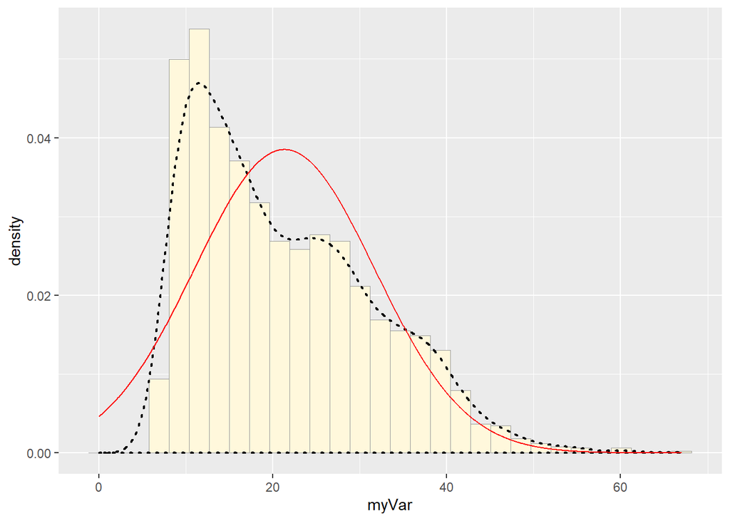

### Plot exponential probability density

Now let’s use the same template and add in the curve for the exponential:

```r
expoPars <- fitdistr(z$myVar,"exponential")
rateML <- expoPars$estimate["rate"]

stat2 <- stat_function(aes(x = xval, y = ..y..), fun = dexp, colour="blue", n = length(z$myVar), args = list(rate=rateML))
 p1 + stat + stat2
```

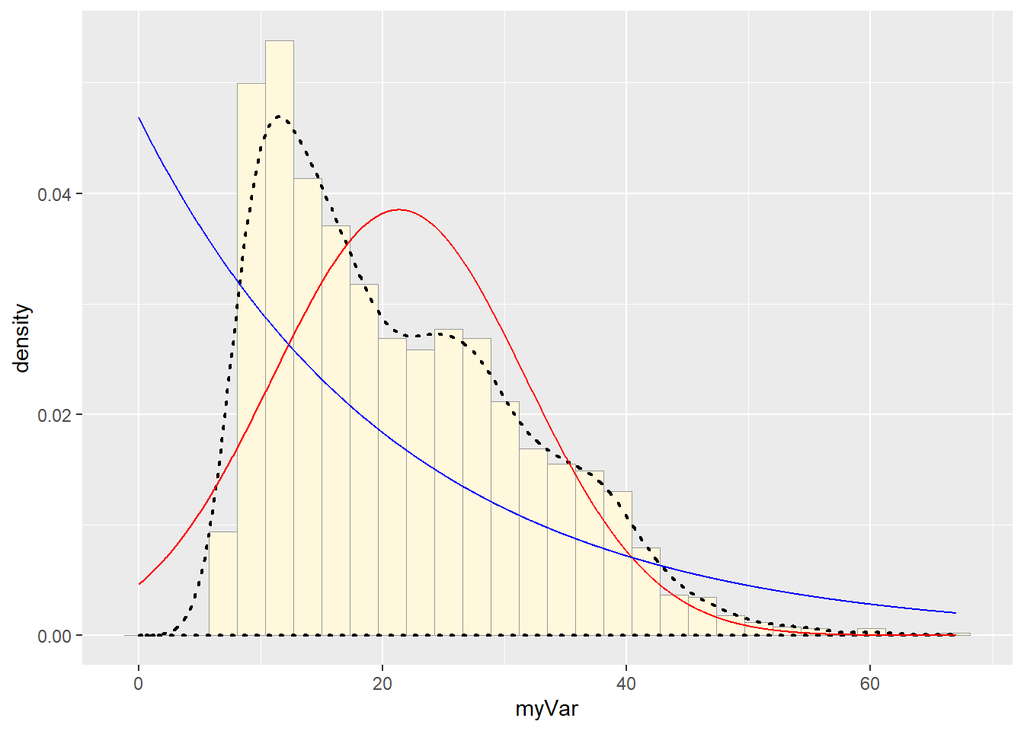

### Plot uniform probability density

For the uniform, we don’t need to use fitdistr because the maximum likelihood estimators of the two parameters are just the minimum and the maximum of the data:

```r
stat3 <- stat_function(aes(x = xval, y = ..y..), fun = dunif, colour="darkgreen", n = length(z$myVar), args = list(min=min(z$myVar), max=max(z$myVar)))
 p1 + stat + stat2 + stat3
```

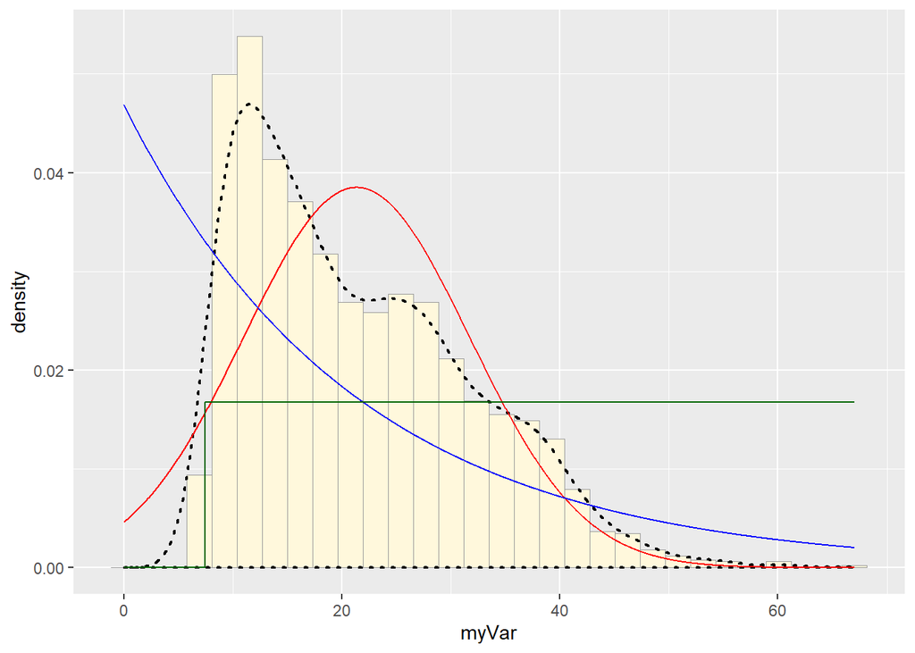

### Plot gamma probability density

```r
gammaPars <- fitdistr(z$myVar,"gamma")
shapeML <- gammaPars$estimate["shape"]
rateML <- gammaPars$estimate["rate"]

stat4 <- stat_function(aes(x = xval, y = ..y..), fun = dgamma, colour="brown", n = length(z$myVar), args = list(shape=shapeML, rate=rateML))
 p1 + stat + stat2 + stat3 + stat4
```

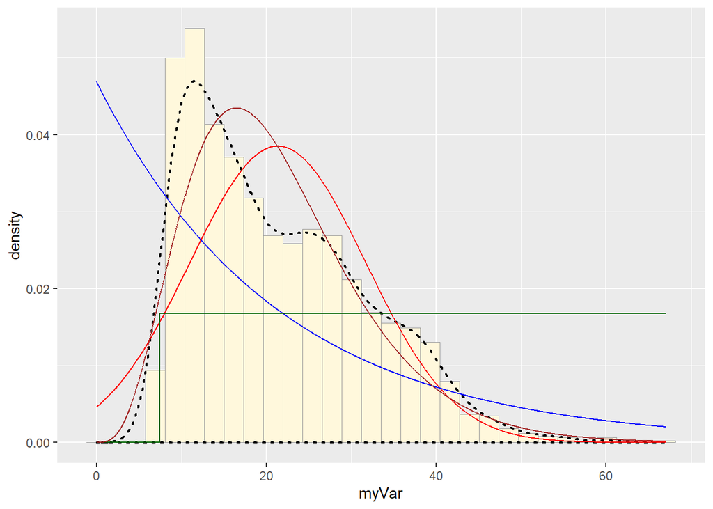

### Plot beta probability density

This one has to be shown in its own plot because the raw data must be rescaled so they are between 0 and 1, and then they can be compared to the beta.

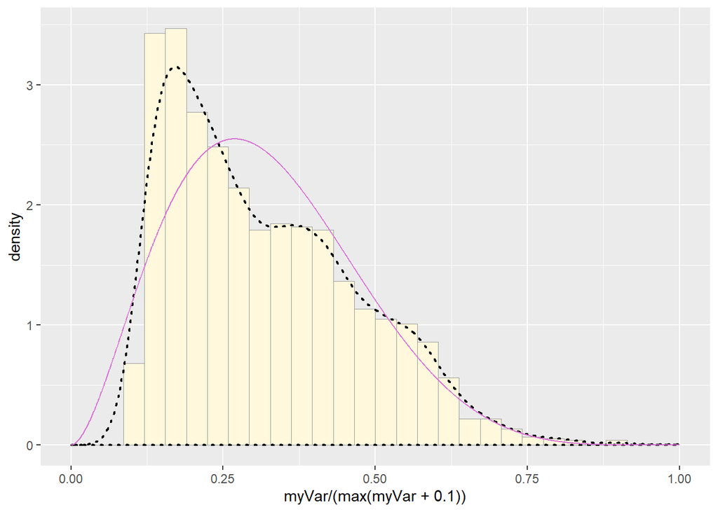

```r
pSpecial <- ggplot(data=z, aes(x=myVar/(max(myVar + 0.1)), y=..density..)) +
  geom_histogram(color="grey60",fill="cornsilk",size=0.2) +
  xlim(c(0,1)) +
  geom_density(size=0.75,linetype="dotted")

betaPars <- fitdistr(x=z$myVar/max(z$myVar + 0.1),start=list(shape1=1,shape2=2),"beta")
shape1ML <- betaPars$estimate["shape1"]
shape2ML <- betaPars$estimate["shape2"]

statSpecial <- stat_function(aes(x = xval, y = ..y..), fun = dbeta, colour="orchid", n = length(z$myVar), args = list(shape1=shape1ML,shape2=shape2ML))
pSpecial + statSpecial
```